# actdatos

2022-09-20

## Ejercicio 1

Definimos la función $h(x)=\frac{1}{\sqrt{x}}$, notemos que $h'(x)=-\frac{1}{2x^{3/2}}$. Ahora con el teorema del método Delta vamos a demostrar que si $\sigma_{y}\propto [\mathbb{E}(y)]^{3}$, la transformación $Y=h(y)$ para la variable $y$ estabiliza la varianza. Con esto solo desarrollamos lo siguiente:

$Var(h(y))\approx (h'(\mu_{y}))^2\sigma^{2}_{y}=[-1/(2(\mu_{y})^{3/2})]^2\sigma^{2}_{y}=\frac{\sigma_{y}^2}{4\mu_{y}^3}\propto \frac{\mu_{y}^{3}}{4\mu_{y}^3}=\frac{1}{4}$

Con esto último, hemos demostrado que la $\sigma_{y}$ es proporcional a una constante, con lo cual se ha estabilizado la varianza. Es decir, $\frac{1}{\sqrt(y)}$ tiene varianza constante.

## Ejercicio 2

A continuación, demostraremos que la transformación Box-Cox(como función de $\lambda$) es continua en $\lambda=0$, para esto bastará demostrar que $\lim_{\lambda\to 0}y(\lambda)=y(0)$, esto es quivalente a demostrar que $\lim_{\lambda\to 0}\frac{y^{\lambda}-1}{\lambda(\dot{y})^{\lambda-1}}=\dot{y}\log{y}$. Con lo cual, procedemos a desarrollar aplicando L’Hopital (teniendo en cuenta que se cumplen las condiciones):

$\lim_{\lambda\to 0}\frac{y^{\lambda}-1}{\lambda(\dot{y})^{\lambda-1}}=\lim_{\lambda\to 0}\frac{y^{\lambda}\log{y}}{(\dot{y})^{\lambda-1}+\lambda(\dot{y})^{\lambda-1}\log{\dot{y}}}=\dot{y}\log{y}$

Queda demostrado entonces que la transformación Box-Cox es continua en $\lambda=0$

## Ejercicio 3

En este ejercicio nos enfocaremos en encontrar la relación entre el consumo de agua (medido en m3/mes) y electricidad (medido en kw/hr) de una ciudad, tomando en cuenta un estudio que supuso que había alguna relación.

### a) Grafique los datos y comente

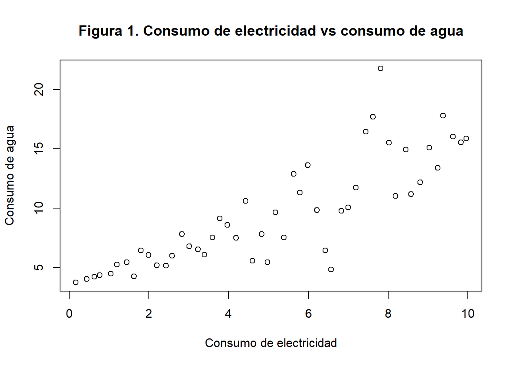

Se puede observar en la figura 1 que la relación entre consumo de electricidad y agua es positiva. A simple vista son notables dos datos: el par (7.8, 21.7) tiene un valor muy alto de consumo de agua para la cantidad de electricidad consumida y el par (6.5, 4.8) tiene un consumo muy bajo de agua para ese nivel de electricidad. Más aún, a medida que el consumo de electricidad aumenta, el consumo de agua se dispersa más, lo que nos indica que quizá la varianza no es constante, si no que aumenta a medida que aumenta el consumo de electrcidad.

### b) Ajuste un modelo de regresión lineal simple sobre los datos sin transformar

Creamos un modelo dados los datos que tenemos sin hacer ninguna transformación preliminar:

**Figura 2. Salida del modelo de regresión lineal simple construido en R**

```
##
## Call:
## lm(formula = c.agua ~ c.elec, data = datos)
##
## Coefficients:
## (Intercept)       c.elec
##       2.884        1.302
```

En la figura 2 observamos que nuestro modelo lineal estima una recta con ordenada al origen de 2.884 y pendiente 1.302, con lo cual nuestra recta ajustada comparada con los datos queda de la siguiente forma:

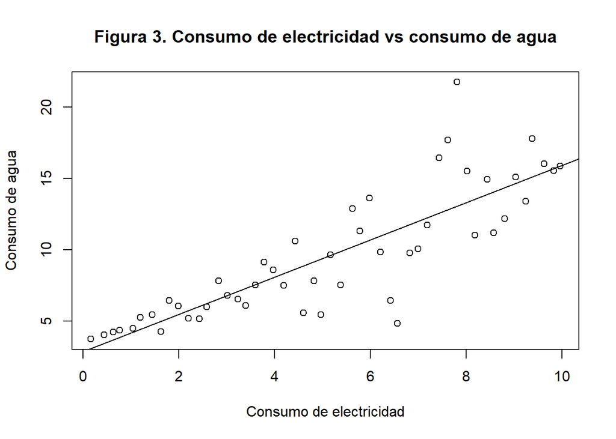

A simple vista, en la figura 3, podemos pensar que nuestro modelo se ajusta bien a los datos en general, en particular cuando el consumo de electricidad es pequeño. Sin embargo, conforme el consumo de electricidad es mayor, se observa que los datos presentan mayor variabilidad. Con lo observado, podríamos concluir que podrían haber ciertos supuestos que no se estarían cumpliendo, como una variabilidad constante en nuestros datos.

### c)Verifique su modelo via análisis de residuales. Comente

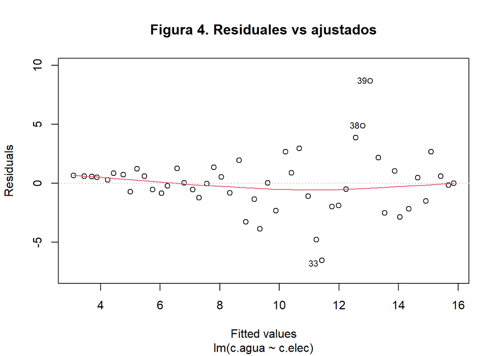

En la gráfica de residuales (de la figura 4) observamos lo siguiente: se observa que la dispersión para los datos es mayor para valores grandes de la respuesta ajustada (lo que indica varianza no constante); dado que los datos estaban ordenados, es claro que a mayor respuesta ajustada (y posición del residual) mayor varianza. Estas tendencias podría indicarnos que los residuales no se distribuyen de manera aleatoria o que no tienen varianza constante, por lo que habría que encontrar alguna transformación de los datos que nos ayude a normalizar la varianza y distribución de los residuales de tal forma que nuestro modelo se ajuste de forma adecuada a los datos y supuestos.

**Figura 5. Resumen del modelo**

```
##
## Call:
## lm(formula = c.agua ~ c.elec, data = datos)
##
## Residuals:
##     Min      1Q  Median      3Q     Max
## -6.5679 -1.1952  0.0255  0.8739  8.6796
##
## Coefficients:
##             Estimate Std. Error t value Pr(>|t|)
## (Intercept)   2.8841     0.7067   4.081 0.000168 ***
## c.elec        1.3023     0.1205  10.805 1.89e-14 ***
## ---
## Signif. codes:  0 '***' 0.001 '**' 0.01 '*' 0.05 '.' 0.1 ' ' 1
##
## Residual standard error: 2.46 on 48 degrees of freedom
## Multiple R-squared:  0.7087, Adjusted R-squared:  0.7026
## F-statistic: 116.8 on 1 and 48 DF,  p-value: 1.887e-14
```

Según los estadístidos mostrados en la figura 5, el valor $R^{2}$ es de 0.7087, es decir, nuestro modelo logra explicar moderadamente la variabilidad del modelo. También, el error de los residuales es de 2.46 con 48 grados de libertad. Tanto los valores estimados de la ordenada como el regresor (consumo de electricidad) son significativos para este modelo, con lo cual tenemos seguridad de que al menos son distintos de cero.

### d) Box - Cox con un intervalo de confianza del 90%

El valor de $\lambda$ que minimiza la suma de cuadrados de los residuales es -0.15. Luego, el intervalo de confianza contiene a todas las lambdas para las cuales la suma de cuadrados de los residuales es menor a 200, como se observa en la figura 6. Obtenemos el siguiente intervalo (para la partición utilzada, de -2 a 2 en saltos de 0.05): $\lambda \in [-0.55,0.25]$ Este intervalo contiene al cero, por lo tanto utilizamos ese valor para transformar la respuesta; esto es, $Y = \log(y)$

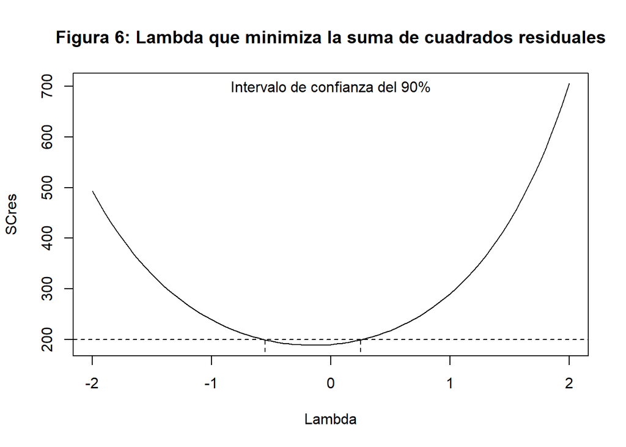

### e) Grafique $y^{(\lambda)} vs x$

Usamos $\lambda$ = 0, luego $Y = y^{(\lambda)}=log(y)$, y procedimos a construir el nuevo diagrama de dispersión con su respectivo modelo ajustado para los datos transformados en la figura 7.

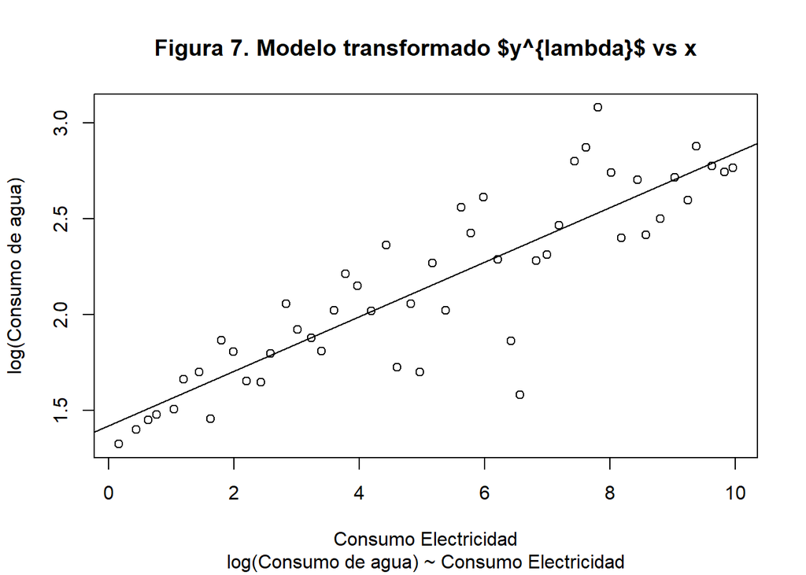

### f) Ajuste el modelo correspondiente y valídelo. Comente.

**Figura 8. Estimados del modelo**

```
##
## Call:
## lm(formula = y.ajustada ~ x)
##
## Coefficients:
## (Intercept)            x
##      1.4195       0.1422
```

En la figura 8, se observa que nuestro modelo estima una ordenada al origen igual a 1.4195, y una pendiente de .1422. Ahora, notemos que el modelo ajustado predice $\log(y)$, por lo que para obtener $y(x)$ tendríamos la siguiente ecuación: $y = e^{1.4195+0.1422x}$.

Después, procedimos a analizar los residuales con respectos a los valores ajustados:

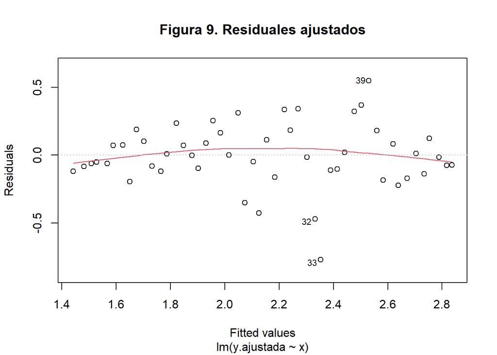

Observamos en la figura 9 que los residuales del modelo ajustado se comportan de manera aleatoria, pues ya no se ve una tendencia tan definida como se veía en el modelo sin transformar Además, la varianza es mucho más constante. Aunque la varianza aún es menor en los extremos, esto es mucho menos marcado que en el modelo original. Esto nos indica que con la transformación se cumplen mejor los supuestos, y por lo tanto podemos ajustar el modelo de regersión lineal de mejor manera.

**Figura 10. Resumen modelo ajustado**

```
##
## Call:
## lm(formula = y.ajustada ~ x)
##
## Residuals:
##      Min       1Q   Median       3Q      Max
## -0.77154 -0.10837 -0.00734  0.12186  0.54868
##
## Coefficients:
##             Estimate Std. Error t value Pr(>|t|)
## (Intercept)  1.41951    0.06696   21.20   <2e-16 ***
## x            0.14222    0.01142   12.45   <2e-16 ***
## ---
## Signif. codes:  0 '***' 0.001 '**' 0.01 '*' 0.05 '.' 0.1 ' ' 1
##
## Residual standard error: 0.233 on 48 degrees of freedom
## Multiple R-squared:  0.7637, Adjusted R-squared:  0.7587
## F-statistic: 155.1 on 1 and 48 DF,  p-value: < 2.2e-16
```

La $r^{2}$ aumentó de 0.70 en el modelo sin transformar a 0.76 en el modelo transformado; sin embargo, dado que transformamos la respuesta, no es posible comparar estos valores. Por otro lado, vemos que tanto la ordenada como el regresor continúan siendo significativos, y que los residuales son mucho más pequeños y con mucha menor dispersión que en el modelo sin transformar ($RIQ_{transformado}=0.23023$ vs $RIQ_{transformado}=2.0691$.

### g) Intervalo al 90% para el consumo medio de agua esperado si el consumo de energía eléctrica es de 7.57 kw/hr

Como el modelo predice log(y), obtendremos el intervalo de confianza para los valores transformados, y a continuación exponenciamos los límites del intervalo para obtener el intervalo de la variable sin transformar.

El intervalo es:
$$y_{predict} \pm
t(.95,48)^{*}S^{*}\sqrt{\frac{1}{n} +
\frac{(x_0-\bar{x})^2}{S_{xx}}}$$
, donde, si $Y = log(y)$ tenemos: $S = \sqrt{\frac{1}{48}*\sum_{i=1}^{50}{(\hat{Y_i}-Y_i)^2}}$ y $Sxx = \sum_{i=1}^{50}{(x_i-\bar{x})^2}$

Obtenemos un intervalo transformado de $\hat{Y}(7.57)=\log(\hat{y}(7.57))\in(2.4234,2.5688)$; si exponenciamos los límites, obtenemos las unidades originales de la respuesta, y obtenemos el intervalo $\hat{y}(7.57)\in(11.2841,13.0504)$ con confianza al 90% para el consumo medio de agua esperado si el consumo de energía eléctrica es de 7.57 kw/hr

### h) Intervalo de prediccción al 95% si el consumo de energia es de 5.1 kw/hr

El intervalo teórico ahora es:
$$y_{predict} \pm
t(.975,48)^{*}S^{*}\sqrt{1+\frac{1}{n} +
\frac{(x_0-\bar{x})^2}{S_{xx}}}$$